# STOR 455 Homework #2

#### MODEL #2: Again use Mileage as a predictor for Price, but now for new data

13. Select a new sample from the UsedCar dataset using the same *Model* vehicle that was used in the previous sections, but now from vehicles for sale in a different US state. You can mimic the code used above to select this new sample. You should select a state such that there are at least 100 of that model listed for sale in the new state.

```r
StateHW3 = "GA"

# Creates a dataframe with the number of each model for sale in Georgia
GAvehicles = as.data.frame(table(UsedCars$Model[UsedCars$State==StateHW3]))

# Renames the variables
names(GAvehicles)[1] = "Model"
names(GAvehicles)[2] = "Count"

# Restricts the data to only models with at least 100 for sale
# Vehicles from non US companies are contained in this data
# Before submitting, comment this out so that it doesn't print while knitting
Enough_Vehicles = subset(GAvehicles, Count>=100)
Enough_Vehicles
```

|  | Model | Count |
| --- | --- | --- |
| 24 | 200Limited | 206 |
| 37 | 3 | 451 |
| 60 | 4 | 103 |
| 72 | 5 | 310 |
| 93 | 7 | 164 |
| 128 | AcadiaFWD | 285 |
| 135 | Accord | 782 |
| 138 | AccordEX-L | 125 |
| 139 | AccordLX | 121 |
| 146 | Altima2.5 | 887 |

[output cut: 108 more lines]

```r
ModelOfMyChoice = "CamaroCoupe"

# Takes a subset of your model vehicle from Georgia
MyGAvehicles = subset(UsedCars, Model==ModelOfMyChoice & State==StateHW3)

# Check to make sure that the vehicles span at least 6 years.
range(MyGAvehicles$Year)
```

```
[1] 2012 2018
```

14. Calculate the least squares regression line that best fits your new data and produce a scatterplot of the relationship with the regression line on it.

```r
GAvehicleModel = lm(Price~Mileage, data = MyGAvehicles)
GAvehicleModel
```

```
Call:
lm(formula = Price ~ Mileage, data = MyGAvehicles)

Coefficients:
(Intercept)      Mileage
 27734.5444      -0.1697
```

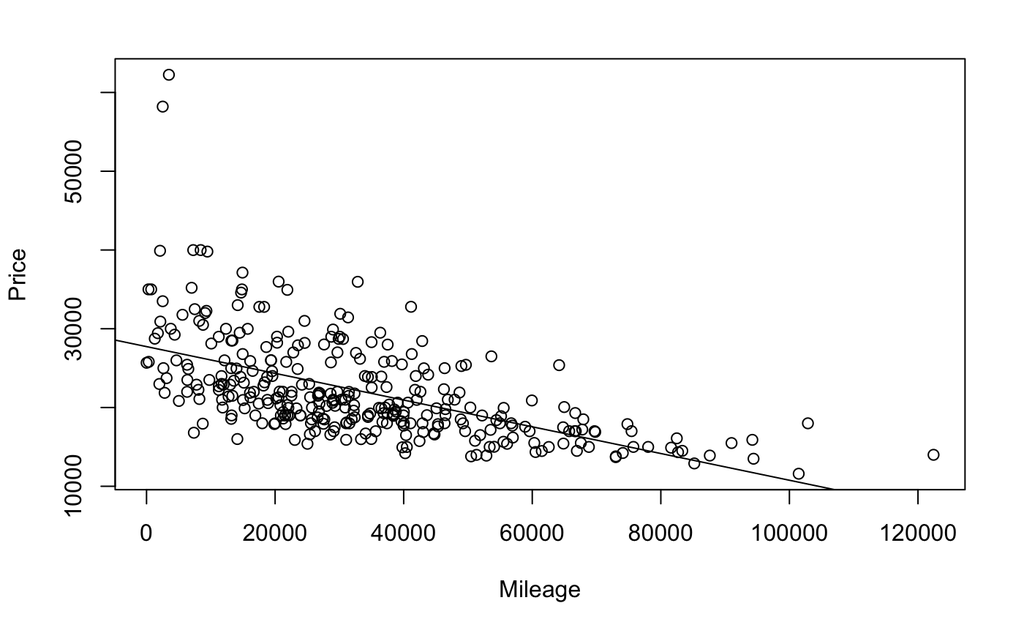

```r
plot(Price~Mileage, data = MyGAvehicles)
abline(GAvehicleModel)
```

15. How does the relationship between *Price* and *Mileage* for this new data compare to the regression model constructed in the first section? Does it appear that the relationship between *Mileage* and *Price* for your *Model* of vehicle is similar or different for the data from your two states? Explain.

```r
GAvehicleModel$coefficients
```

```
  (Intercept)       Mileage
27734.5444087    -0.1696889
```

```r
VehicleModel$coefficients
```

```
  (Intercept)       Mileage
30736.6457327    -0.2182968
```

```r
# The relationship is similar as both are negatively correlated
# The relationships are slightly different as in Georgia the price and miles are cheaper
```

16. Again suppose that you are interested in purchasing a vehicle of this model that has 50,000 miles on it (in 2017) from your new state. How useful do you think that your model will be? What are some possible cons of using this model?

```r
# The model will be super helpful as it will allow me to save lots of money
# A con is that there isn't the greatest correlation between mileage and price
# That lack of correlation could make the model inaccurate
```